# III Congreso y XIV Jornadas de Usuarios de R

Joaquín Planelles e Isabel Padilla

6 al 8 de noviembre de 2024

# El ciclo de vida del dato

En cualquier trabajo con datos hay distintas fases. Típicamente el proceso comienza con la lectura/captación de la información. Y esto puede implicar acciones muy diversas. En unos casos serás tú mismo el que capte esa información (preguntando, observando, sensorizando) y en otras ocasiones -las más- reutilizarás información que ha sido captada por terceros con fines distintos a la producción de estadísticas o modelización de los datos. En otras ocasiones acudirás a información menos estructurada, haciendo Web-scrapping o tratando imágenes.

Una vez has captado la información, el siguiente paso es la transformación de la estructura y contenido de tu set de datos. Esta segunda fase, dedicada al tratamiento de datos, es la “patito feo” del ciclo de vida del dato. Le falta el atractivo que tienen las fases siguientes, centradas en la modelización y la comunicación. No obstante, por experiencia sabemos que una parte significativa del tiempo total de un trabajo de calidad se dedica a este tipo de operaciones. Esto es así en cualquier análisis de datos, pero en mayor medida en el caso de la producción estadística pública.

Siendo esto así, existen distintas herramientas para abordar el tratamiento de datos. Una de ellas, que en nuestra organización está cada vez más presente, son precisamente un conjunto de librerías de R/tidyverse que generan scripts sencillos, permiten industrializar e integrar los procesos, así como obtener una respuesta eficiente en tiempos de procesamiento.

El objetivo de este taller es facilitar algunos scripts que a nosotros nos han resultado útiles a la hora de acceder a información, y también para transformarla. Se trata de un muestrario de soluciones que nosotros hemos implementado en algún proyecto y que pensamos que, aunque sea en ámbitos temáticos distintos, o como fase previa a la modelización, a otros usuarios también les pueden resultar útiles.

# Librería dbplyr

[figure not shown]

En el análisis de datos, te enfrentas a dos dificultades: (1) **Qué hacer**. Se trata de establecer los objetivos de tu análisis y la metodología que vas a seguir. Esta dificultad tiene un carácter cognitivo y es propia del dominio al que pertenecen los datos. Por ejemplo, al ámbito del medio ambiente, el mercado de trabajo, la salud, etcétera. (2) **Hacerlo**. Esta segunda dificultad tiene un carácter computacional.

Por supuesto, una vez has pensado qué hacer y lo has implementado, también habrás adquirido un conocimiento adicional sobre el ámbito en estudio y sobre los datos que estás explotando. Te planteas nuevas preguntas y, poco a poco, a través de un proceso iterativo que te lleva de la dificultad (1) a la (2) y de vuelta a la (1) lo que empezó siendo un análisis exploratorio/rudimentario pasa a ser un auténtico análisis de datos.

La filosofía de `tidyverse` es simplificar al máximo la parte computacional, para poder dedicar el tiempo a lo que de verdad importa: pensar qué hacer. Tomemos el ejemplo de la librería central de este curso, la librería `dplyr`. Esta librería dispone de 6 verbos/funciones principales (`select`, `filter`, `arrange`, `mutate`, `group_by` y `summarise`). Con estas 6 piezas, que conectamos entre si mediante tuberías, puedes realizar casi cualquier tratamiento de datos que imagines. Has simplificado el problema a construir tu lego (script) a partir de las 6 piezas de las que dispones. El código que te queda es sencillo y legible. También es interoperable con otras librerías de `tidyverse`, concebidas para otras fases del ciclo del dato: modelización, visualización, etc.

No obstante, con frecuencia tus datos estarán alojados en una base de datos relacional, que lo que entenderá no es R, sino lenguaje SQL. En nuestro trabajo también es frecuente recibir la información en un texto plano que unas veces te interesará leer directamente desde R, pero en otras ocasiones te interesará empezar por alojar en una base de datos relacional. Los motivos que típicamente te llevan a ello son la seguridad (control de accesos, diferenciación de roles) y el tamaño (porque tu conjunto de datos sea más grande que la memoria RAM de tu ordenador, o lo sufucientemente grande como para comprometer el rendimiento).

¿Qué hacer en estos casos? ¿Debes renunciar a los sencillos scripts que obtienes con `tidyverse`? La respuesta es ¡¡Noooo!! No es necesario, porque te puedes conectar a la base de datos directamente desde R. Y ahora viene lo mejor: una vez conectado puedes usar la librería `dbplyr`, que transforma tu script de R en un script optimizado de SQL. Esta transformación se realiza, a no ser que le indiques otra cosa, de un modo que es ciego para el usuario, que solo visualiza su script de R. De este modo, te puedes quedar con lo mejor de los dos mundos: la sencillez e interoperabilidad de tu código `tidyverse` y externalizar las operaciones más pesadas para que las realice directamente el motor de tu base de datos. Así liberarás la memoria RAM de tu ordenador y ganarás en tiempos/velocidad de procesamiento… ¡Marie Kondo estaría orgullosa!

### **Problemas de memoria**

Si trabajas con gran cantidad de datos desde R, no te serán ajenos mensajes como el siguiente en el que el programa te advierte de que, simplemente, no le da. El problema es que R tiene limitaciones al trabajar con grandes volúmenes de datos, ya que consume recursos de la memoria volátil (RAM) del ordenador.

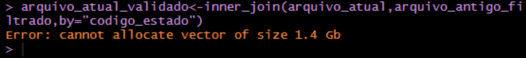

Incluso, cuando insistes en pedirle más de lo que puede ofrecerte, te puede llegar a aparecer un mensaje muy gráfico que te invita a salir y a reiniciar la sesión de R:

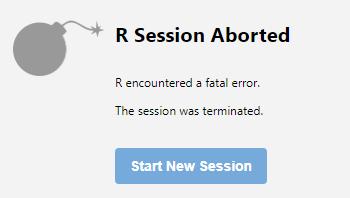

Una situación no tan extrema como las anteriores, pero mucho más frecuente, se da cuando el volumen de datos no llega a colapsar tu ordenador, pero sí afecta a su rendimiento. ¿Qué hacer? En esta sección propondremos distintas estrategias de acción, aunque pondremos el énfasis en la conexión a bases de datos y en el uso de la librería `dbplyr`. Como veremos, se trata de una solución elegante y muy potente, que te permite trabajar desde R con cientos de millones de registros, si es necesario. Pero primero asegúrate de que es la solución ideal para ti.

La solución más adecuada para cada caso dependerá de un amplio conjunto de factores: equipos informáticos, conocimientos y lo más importante, tiempo (tiempo de aprendizaje, tiempo de procesamiento y tiempo de elaboración de los scripts). Queremos subrayar que la mejor solución no será siempre la solución que computacionalmente hubiera sido más eficiente (de hecho, rara vez lo es). Quizás la mejor solución para tu problema no requerirá conectarte a una base de datos externa sino que te bastará con optimizar su script, o con ampliar tu memoria RAM. Dicho de otro modo, con la computación también opera una ley de rendimientos marginales decrecientes. Y hay costes de oportunidad.

#### **Interacción entre R y la base de datos.**

Lo primero será establecer esa conexión con la base de datos, lo que dependerá de ciertos parámetros: paths, drivers, puertos, contraseñas… También dependerá de cuál sea el sistema gestor de bases de datos donde esté alojada la inforamción que quieres exlotar.

[figure not shown]

[figure not shown]

Una vez establecida la conexión a la base de datos, ya ha llegado el momento de comunicarse con ella. ¡Ojo! Después del esfuerzo por establecer la conexión con la base de datos, lo que nos conviene es externalizar en ella el trabajo más pesado. Si no, como se suele decir, ‘hemos hecho un pan como unas tortas’. La idea, repetimos, es comunicarnos con la base de datos en su idioma (SQL) y que sea ella la que haga el trabajo pesado, liberando recursos de nuestro equipo y ganando tiempo de procesamiento

# Eurostat - INE - IECA

En segundo lugar, vamos a hablar de algo que es muy habitual en nuestro trabajo: acudir a los datos que ha publicado en su página Web algún organismo estadístico. Esto se puede hacer de una manera artesanal, navegando por la web. Pero para determinados procesos, es más eficiente industrializarlo y acceder a los datos directamente desde R. En lo que sigue os vamos a mostrar cómo acceder a datos del INE, del IECA y de EUROSTAT de una forma industrial. Si tú estás interesado en otros proveedores de infromación, aunque éstos no sean pertenecientes al ámbito estadístico, seguramente ofrecerán soluciones similares para facilitar el acceso a sus datos, pues al fin y al cabo los proveedores de información desean que sus datos se usen y reutilicen.

### **Lectura de datos de EUROSTAT.**

La librería **eurostat** es una API que permite el acceso a los datos de Eurostat. Los comandos de esta librería permiten buscar, descargar, manipular y visualizar datos. Aquí solo vamos a poner un ejemplo de como acceder a los datos pero podéis ampliar información en el siguiente enlace. [Tutorial eurostat](https://ropengov.github.io/eurostat/articles/eurostat_tutorial.html)

**¡Atención!** Hemos podido comprobar que el desempeño de la librería es altamente dependiente de la versión de R que tengáis instada. Para que funcione sin problemas, debes disponer/instalar versiones >= 4.2.2

El organismo que proporciona datos estadísticos oficiales a nivel de Europa es Eurostat. Produce y recopila información de los países de Unión Europea. Esta información nos permite hacer comparativas entre países según distintos ámbitos (economía, demografía, salud…). Eurostat organiza la información en un arbol temático tal y como mostramos en la imagen. Podemos navegar por las distintas carpetas hasta llegar a la tabla que queremos descargar. A él podemos llegar accediendo a la web mediante el siguiente [link](https://ec.europa.eu/eurostat), pinchando en el icono DATABASE

[figure not shown]

Para descargar información de la base de datos de Eurostat usaremos la librería **eurostat** que contiene muchas funciones. Aquí os mostramos un par de ejemplos de como descargar tablas que ya están predefinidas/ visibles en la web de Eurostat pero también hay otras herramientas para buscar en la base de datos con más libertad.

Dos de los principales comandos de la librería son: `search_eurostat()` y `get_eurostat()`. El primero nos permite hacer busquedas por nombres de tablas, palabras claves o temática. Además, este comando tiene un argumento `type =` donde podemos indicar si la selección buscada es dataset, carpeta o tabla. El segundo comando, `get_eurostat()`, carga directamente la tabla desada como un dataset de datos de R. Veamos dos ejemplos para entender mejor el funcionamiento de estos comandos.

**Ejemplo1** Supongamos que queremos buscar todos los datasets que contienen información sobre ingresos:

```r
library(eurostat)
#search_results <- search_eurostat("income",type = "dataset")
```

Una vez ejecutada esta línea, obtenemos un tibble con el listado de tablas que contienen la palabra “ingreso”, de este modo, podemos encontrar toda la información que contiene la base de datos relativa a algún tema que nos interese. Esta tabla tiene una serie de columnas:

- title: Nombre de la tabla.
- code: es el código de la tabla necesario para descargar los datos con el comando `get_eurostat()` y cuyo funcionamiento veremos en el ejemplo2. Se trata de un identificador único para cada conjunto de datos.
- type: tipo de dataset a buscar. Puede ser una tabla, una carpeta o las dos cosas.
- last.update.of.data: última actualización de los datos.
- last.table.structure.change: fecha del último cambio en la estructura de la tabla.
- data.start: dato más antiguo disponible.
- data.end: dato más reciente disponible.
- values: número de valores incluidos en el dataset.
- hierarchy: Jerarquía del árbol de navegación de datos, representada en el archivo de texto original mediante un prefijo de sangría de 4 espacios en el título.

**Ejemplo2** Supongamos que queremos obtener datos de población según sexo y ocupación, es decir, tenemos clara la tabla del árbol temático a descargar. Se trata de la tabla que marcamos en la imagen siguiente:

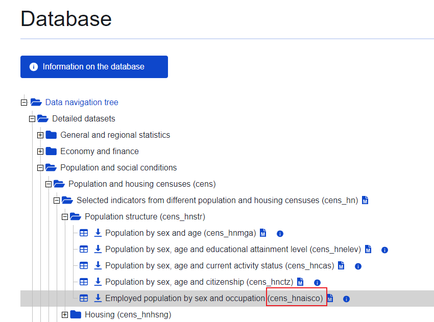

Una forma de extraer los datos combinando los comandos `search_eurostat()` y `get_eurostat()` es la que mostramos en los siguientes pasos:

1. Navegamos sobre el árbol temático hasta encontrar la tabla a descargar.
2. Copiamos el título de la tabla/carpeta y lo pegamos en el comando `search_eurostat()`
3. El resultado de la acción anterior nos proporciona una tabla con una columna **code** que contiene el identificador del dataset. En **id** almacenamos el valor de la columna **code**
4. Con el comando `get_eurostat()` cargamos los datos en la consola. El primer argumento de la función `get_eurostat()` será **id**, es decir, el valor del campo **code** que es único para cada set de datos.

```r
library(eurostat)
# Paso 2
#search_results <- search_eurostat("Employed population by sex and occupation",type = "dataset")
# Paso3
#id <- search_results$code[1]
# Paso4
#datos <- get_eurostat(id, time_format = "num", stringsAsFactors = TRUE)
```

### **Lectura de datos del INE.**

Para estudiar la intensidad de un fenómeno, se usan con frecuencia las tasas. Se trata de indicadores que ponen en relación el número de sucesos (por ejemplo, los nacimientos que hayan tenido lugar) respecto a la población total de ese territorio. Es decir, en el cálculo de tasas se usan como denominadores datos relativos a la población residente en el territorio en cuestión. En lo que sigue, vamos a poner un ejemplo que muestre cómo acceder a datos del INE, de un modo que lo puedas dejar programado en tu script. Una vez montado, te evitarás tener que acceder a la página web para buscarlo. Como ejemplo, vamos a mostrar cómo acceder a datos de población del INE, tan necesarios para calcular indicadores.

Desde 2021 (tras la elaboración del Censo), el INE elabora una operación que denomina “Estadística Continua de Población”. Esta operación proporciona una medición cuantitativa trimestral de la población residente en España y en viviendas familiares a distintos niveles de desagregación territorial y según características demográficas básicas. Para el caso de lectura de datos en el INE os vamos a mostrar dos opciones:

**OPCIÓN1: Lectura de datos del INE** Una forma de obtener esta información es mediante la librería `pxR`. Una vez hayáis istalado la librería, ya podéis trabajar con ella. La forma de proceder os la mostramos a continuación:

- 1.- Sobre la flecha marcada en la tabla hacemos click

[figure not shown]

- 2.- Se nos abrirá un cuadro de diálogo con los distintos formatos de descarga de datos. Nosotros, en esta sección vamos a usar el PCAxis. Sobre este formato, hacemos click con el botón derecho y aparecerá otro cuadro de opciones

[figure not shown]

- 3.- Una vez aquí, marcamos **copiar dirección del enlace**. Esta ruta es la que vamos a pegar dentro del comando `read.px()`

```r
IND_E<-read.px("https://www.ine.es/jaxiT3/files/t/es/px/59239.px?nocab=1") %>% as.data.frame()
```

**OPCIÓN2: Otra forma de leer los datos del INE** Otra forma de cargar los datos del INE en R es utilizando el comando de lectura en formato `csv`. Para ello copiamos la dirección del enlace en el cuadro de opciones anterior de **descarga de ficheros** y hacemos click con el botón derecho sobre **csv separado por ;**. Esta dirección copiada es la que usamos en el comando read.csv para la descarga de datos en este formato.

```r
url <- 'https://www.ine.es/jaxiT3/files/t/es/csv_bdsc/59583.csv?nocab=1'
datos <- read.csv(url,sep=';')
```

### **Lectura de datos del IECA.**

En tu trabajo te puede interesar generar tus propias funciones, a las que puedas después llamar ‘a demanda’. De hecho, en una pestaña posterior de este taller veremos cómo se crean funciones en R. A veces querrás facilitarle el acceso a esas funciones/rutinas a personas en concreto. O si crees que la rutina que has montado puede ser útil para un público más amplio y te sientes generoso, puedes darle el formato de librería y permitir que otros usuarios se instalen tus funciones. Esto lo puedes hacer de distintas formas. Una es llevar esa librería que has creado a CRAN (el repositorio oficial de R). Pero ojo, que el repositorio oficial CRAN no contiene todas las librerías/rutinas de R que puedes utilizar. Puedes encontrar muchas otras librerías en espacios como github, gitlab… De hecho, incluso en los casos en los que pretendas acabar subiendo la librería a CRAN, normalmente querrás que la librería empiece siendo una versión de desarrollo o “versión beta” para probarla y obtener feed-back, como paso previo al “gran público”.

Como ejemplo, os vamos a hablar de una librería desarrollada por personal del IECA (Cristina Fernández & María Escudero) que se denomina precisamente `IECA`. Como aún es una versión de desarrollo, os facilitamos el contacto de una de las autoras (María), a la que podéis trasladar cualquier cuestión/comentario/sugerencia relativa a la librería. Nuestro objetivo como productores de datos es facilitarle la vida a nuestros usuarios, por lo que los comentarios son bienvenidos y se tendrán en cuenta: maria.escudero@juntadeandalucia.es

**librería(IECA)** Permite leer ficheros JSON procendentes de todos los productos publicados en BADEA (Banco de Datos Estadísticos de Andalucía). Por ejemplo, todas las tablas que ofrecemos en la Web del Instituto de Estadística y Cartografía de Andalucía. Si utilizas de manera intensiva datos de nuestra Web, o de otro organismo de la Junta de Andalucía que difunda con esta herramienta (BADEA), esta librería puede ahorrarte mucho trabajo repetitivo.

La librería contiene el comando `lee_badea()` con el que podemos cargar en R los datos en formato JSON que se publican en las distintas consultas de la web. Solo hay que tener en cuenta una cosa. ¡¡Advertencia!! si queremos hacer una selección distinta a la que viene predefinida en la consulta. Por ejemplo, si queremos seleccionar otros periodos, debemos comenzar por filtrarlos, pues el enlace/dirección JSON cambiará al filtrar los datos.

**Instalación** Os hemos facilitado la librería en la documentación del taller avanzado, en un fichero comprimido. Para instalarla vamos a la pestaña `packages` de RStudio y hacemos click en Install. ¡Ojo! Para cargar paquetes/librerías de esta manera, conviene que mantengas el formato comprimido/zip

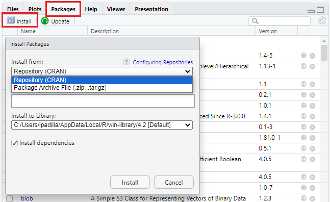

**Ejemplo** Una vez tenemos instalada la librería, veamos un ejemplo, con datos de la ECTA (Encuesta de Coyuntura Tusrística de Andalucía). Se trata de una encuesta que realiza trimestralmente el IECA y que ofrece información turística desde el lado de la demanda:

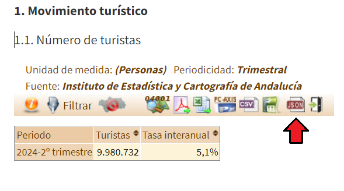

Sobre los datos aparece una barra de iconos. Pinchamos sobre el icono que indica que es un fichero JSON y se nos abrirá un cuadro de diálogo sobre el que tenemos que hacer click en “Copiar enlace”. Dirección que añadiremos al comando `lee_badea` de la siguiente forma:

```r
library(IECA)

lee_badea("https://www.juntadeandalucia.es/institutodeestadisticaycartografia/intranet/admin/rest/v1.0/consulta/232")
```

```
##
##  Inicio: [1] "2024-11-06 23:41:49"
##
##  Fin del proceso de lectura: [1] "2024-11-06 23:41:50"
##
##  Tiempo transcurrido: 1.77 segundos
```

```r
Datos<- ID_232_data
head(Datos)
```

```
##   dim_Trimestral med_Tasa interanual med_Turistas
## 1          20243            4.055478     12552352
```

# Lectura de datos de un pdf

El objetivo de esta sección es el tratamiento de información contenida en pdfs. Tanto en la estadística pública como en otros ámbitos es muy común encontrar información en formato pdf pero en algunas ocasiones nos interesa rescatar este contenido con el fin de tratarlo, transformarlo o elaborar gráficos que faciliten la interpretación de la información. En este apartado vamos a mostrar un código R para cargar los datos de un pdf en nuestro entorno de Rstudio.

El ejemplo que hemos tomado para ilustrar este apartado parte de un conjunto de tablas que proporciona la Seguridad Social para la cumplimentación de los mensajes del **Sistema RED**. Se trata de un servicio electrónico ofertado por la **Tesorería General de la Seguridad Social (TGSS)** hacia empresas y profesionales autónomos, el cual permite el contacto directo y el intercambio de información y documentos entre ambos a través de internet. Este sistema se utiliza para tramitar:

- En el caso de las afiliaciones, altas, bajas, variaciones de datos de trabajadores, consultas y petición de informes relativas a trabajadores y empresas…
- Partes de altas y bajas por incapacidad temporal.
- Remisión de certificados por nacimiento y cuidado de hijos.
- Gestión de autorizaciones.

Estas [tablas](https://www.seg-social.es/wps/portal/wss/internet/InformacionUtil/5300/1889/39740/3383/3389) posibilitan que todos estos trámites se codifiquen de forma correcta y de esta manera, son una fuente de información interesante para medir la realidad social de cotizantes y pensionistas.

Existen circunstancias en las que la Seguridad Social tiene que eliminar, añadir o modificar los códigos, es decir, debe adaptarlos a modificaciones legislativas que cambian conceptos en materia laboral. Nos interesaría saber cuáles han sido estos cambios y precisamente este es el ejemplo que queremos ilustrar en este apartado. En primer lugar veremos de forma detallada como extraemos la información de una de las tablas a modo de ejemplo y después, mostraremos el código general utilizado para leer un conjunto de tablas con estructura similar de un listado de pdfs que iremos recorriendo. Estas tablas las almacenamos en un fichero que, pasado un tiempo, comparamos con el mismo fichero extraído en un momento posterior de este modo, detectamos las modificaciones sufridas en las tablas.

Hemos puesto este ejemplo porque cada vez se utilizan más datos provenientes de registros administrativos dentro de la estadística pública. Por un lado el **Código de Buenas Prácticas de las Estadísticas Europeas** establece en su principio noveno la carga no excesiva para los encuestados y por otro, el avance de la tecnología que brinda equipos con gran capacidad y velocidad de procesamiento, han permitido el aprovechamiento y reutilización de la información a nivel individual procedente de diversas fuentes administrativas. Esta información han hecho que las oficinas estadísticas la utilicen en la producción estadística oficial.

El **Instituto de Estadística y Cartografía de Andalucía** recibe periódicamente ficheros con datos que proceden de registros administrativos. Por ejemplo, los datos de la Muestra Continua de Vidas Laborales son una selección aleatoria de los afiliados y/o pensionistas de la Seguridad Social en el año de referencia o también, los ficheros trimestrales de Afiliaciones y Cuentas de Cotización de la Seguridad Social de Andalucía, información relativa a los trabajadores afiliados a los distintos regímenes del Sistema de la Seguridad Social en situación de alta laboral y situaciones asimiladas al alta. Con estos datos el Instituto de Estadística y Cartografía de Andalucía publica una relación de productos. Para la elaboración de estos productos de difusión son necesarias algunas de las tablas que hemos visto en la web de la Seguridad Social ya que los ficheros recibidos, contienen algunas columnas relativas a estas tablas y por tanto,los registros que aparecen el ellas contienen dicha codificación. Por tanto, en estas tablas encontramos la equivalencia entre la codificación y las descripción o significado de cada código.

## Código de lectura de tabla de pdf

En este apartado vamos a mostrar un código compacto que permite leer un conjunto de tablas de la seguridad social (mostradas anteriormente). Nosotros hemos hecho un trabajo previo de identificación de tablas que tiene estructura similar. Han sido clasificadas mediante dos formas de extracción según la estructura que presenta el pdf, de este modo, hemos construido un bucle para cada una de ellas.

Antes de empezar haremos una breve descripción de las librerías empleadas:

`tidyverse`: conjunto de librerías de R concebidas para el trabajo en Ciencia de Datos. Están programadas para facilitar el trabajo en las distintas fases del ciclo del dato.

`tabulapdf`: Tabula es una herramienta multiplataforma escrita en Java para extraer tablas de archivos PDF. Extraer datos de archivos PDF puede ser un desafío y llevar mucho tiempo, y esta herramienta permite extraer tablas en el entorno de Rstudio, llevarlas a una hoja de cálculo CSV o Microsoft Excel mediante una interfaz simple y fácil de usar.

`stringr`: librería específica para el tratamiento de cadenas de texto.

`readODS`: paquete de R que permite leer y escribir ficheros ODS.

```r
library("tabulapdf")
library(tidyverse)
library(readODS)
```

Como hemos comentado anteriormente, seleccionaremos una de las tablas para mostrarla como ejemplo de los pasos a seguir hasta obtener una tabla “limpia” en nuestro entorno de trabajo. La secuencia de acciones es la siguiente:

- **Paso1:** Almacenamos la ruta en la que se encuentra la tabla a extraer. Haciendo botón derecho sobre la web y copiando la dirección del enlace, la obtenemos.

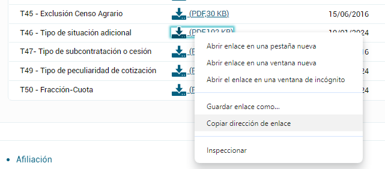

  Vemos que las rutas tienen una parte común y una parte numérica que va variando. Esto nos permite parametrizar la ruta y mediante un bucle, recorrer el listado numérico.

```r
# Tabla46
    j=52
    ruta <- paste0("http://www.seg-social.es/descarga/es/214",600+j)
```

- **Paso2:** Mediante el comando `extract_tables()` de la librería `tabulapdf` extraemos la información del pdf. Esta función devuelve una lista, donde cada elemento de la lista es una tabla. Es bastante versátil, pero como todos los métodos de extracción de tablas en PDF, su éxito depende de la estructura del PDF. Si las tablas no están bien formateadas o están en imágenes, la extracción puede ser menos precisa. Existen tres métodos que podemos indicar en el argumento de la función `method=`:
  - `decide`: es el método predeterminado y es una especie de “auto-selección” entre los métodos “lattice” y “stream”. El algoritmo de la función intentará analizar el contenido de la tabla y decidir automáticamente qué método es el más adecuado en función de la estructura del PDF. Se basa en la estructura visual y en la disposición del contenido de la tabla en el PDF. Es útil cuando no estás seguro de qué método será mejor. Si una tabla está bien estructurada (con líneas claras o sin ellas), este método automáticamente determinará cuál es la mejor forma de extraer la tabla.
  - `lattice`: se utiliza para extraer tablas en PDFs donde las tablas están bien delimitadas por líneas (tanto horizontales como verticales) que crean una cuadrícula o “malla” alrededor de los datos. Se basa en la detección de las líneas de la cuadrícula en el documento PDF. Es más efectivo cuando las tablas están claramente separadas por bordes o líneas visibles.
  - `stream`: El método stream es más adecuado para tablas que no tienen líneas de separación claras, es decir, cuando los datos están organizados en columnas, pero no están delimitados por bordes visibles. En lugar de basarse en líneas, el método detecta los espacios entre los elementos de la tabla para identificar las separaciones entre celdas o columnas. Funciona mejor cuando los datos están alineados de manera consistente, pero no hay líneas de cuadrícula visibles.

Para el ejemplo que nos ocupa el mejor método de extracción es `stream`. También identificamos el número de páginas que tiene el pdf con el comando `get_n_pages()` que nos servirá para recorrer, mediante otro bucle, las hojas del documento para extraer la información.

```r
    tab   <- extract_tables(ruta,  method = c('stream'))
    n_pag <- get_n_pages(ruta)
```

- **Paso3:** Tratamiento de la tabla extraída. En este caso las descripciones de algunos códigos ocupan 2 líneas y mediante el comando `lead()` de dplyr los conseguimos unir en una sola. También nos quedamos solo con las columnas que nos interesan (clave y descripción). Después solo nos quedaría unir las tablas extraídas de cada hoja del pdf.

```r
    tabla<-tibble(Clave=character(),Descripción=character(),id_tabla=numeric())
i=1
    for (i in 1:n_pag) {
      tablai <- tab[[i]]
      tablai <- tablai  %>%
        mutate(Descripción0 = if_else(is.na(lead(Clave)),lead(Descripción),Descripción)) %>%
        mutate(Descripción  = if_else(Descripción0==Descripción | is.na(Descripción0),Descripción,paste(Descripción,Descripción0))) %>%
        filter(!is.na(Clave)) %>% select(Clave,Descripción) %>%
        mutate(id_tabla=600+j,Clave=as.character(Clave))
      tabla <- bind_rows(tabla,tablai)
    }
```

## Código compacto de lectura de tabla de pdf

Este código nos permite la lectura de 43 tablas del listado. En el tibble EXT_NOW tenemos almacenados tanto la clave como la descripción de dichas tablas.

```r
#Librerías cargadas

library("tabulapdf")
library(tidyverse)
library(readODS)


# Creamos una tabla vacía que vamos rellenando.
EXT_NOW <- tibble(Clave=character(),Descripción=character(),id_tabla=numeric())

# Códigos de lectura pdf

#-----------------
# tipo1:26 tablas
#-----------------
for (j in c(1:3,5,6,8,12,23,24,26,37,42,43,50,53,62,71,77,79,82,86,88,90,92,93,94))
{
  #Fijo ruta
  ruta   <- paste0("http://www.seg-social.es/descarga/es/214",600+j)
  tab    <- extract_tables(ruta,  method = c('stream'))
  n_pag  <- get_n_pages(ruta)

  tabla <- tibble(Clave=character(),Descripción=character(),id_tabla=numeric())
  for (i in 1:n_pag) {
  tablai <- tab[[i]]
  tablai <- tablai %>% filter(!is.na(`...2`)) %>%
    mutate(Descripción = if_else(!is.na(Descripción),paste0(`...2`,' ' ,Descripción),`...2`)) %>%
    select(-`...2`,-Comentarios) %>%
    mutate(Descripción0 = ifelse(is.na(lead(Clave)),lead(Descripción),Descripción)) %>%
    mutate(Descripción  = if_else(Descripción0==Descripción | is.na(Descripción0),Descripción,paste(Descripción,Descripción0))) %>%
    filter(!is.na(Clave)) %>% select(Clave,Descripción) %>%
    mutate(id_tabla=600+j,Clave=as.character(Clave))
  tabla <- bind_rows(tabla,tablai)
  }
  EXT_NOW <- bind_rows(EXT_NOW,tabla)
}

#-------------------
#  tipo2: 17 tablas
#-------------------

 for (j in c(7,15,52,58,60,61,63,69,70,73:76,78,80,81,83))
  {
    #Fijo ruta
    ruta  <- paste0("http://www.seg-social.es/descarga/es/214",600+j)
    tab   <- extract_tables(ruta,  method = c('stream'))
    n_pag <- get_n_pages(ruta)

    tabla<-tibble(Clave=character(),Descripción=character(),id_tabla=numeric())
    for (i in 1:n_pag) {
      tablai <- tab[[i]]
      tablai <- tablai  %>%
        mutate(Descripción0=ifelse(is.na(lead(Clave)),lead(Descripción),Descripción)) %>%
        mutate(Descripción=if_else(Descripción0==Descripción | is.na(Descripción0),Descripción,paste(Descripción,Descripción0))) %>%
        filter(!is.na(Clave)) %>%  select(Clave,Descripción) %>%
        mutate(id_tabla=600+j,Clave=as.character(Clave))
      tabla <- bind_rows(tabla,tablai)
    }
    EXT_NOW <- bind_rows(EXT_NOW,tabla)
  }
```

Cada tabla está identificada según la numeración del parámetro `j`de cada ruta. Nosotros hemos establecido una equivalencia entre esta valor y la numeración de la tabla `rutas` del fichero ODS. Para añadir esta información a la tabla, leemos el fichero y lo cruzamos con EXT_NOW. También incluimos la fecha de extracción.

## Almacenamiento de la extracción

Nos interesa tener guardadas las extracciones de las tablas para comprobar los códigos nuevos o los eliminados según aparezcan o desaparezcan de ellas. En primer lugar leemos el fichero donde tenemos almacenadas las urls y creamos un **id_tabla** extrayendo desde la última posción hasta dos menos, de este modo, nos quedamos con los 3 últimos números de ruta de la tabla (números que hemos aprovechado para recorrer las tablas mediante un bucle). Lo hacemos mediante los comandos `str_sub()` y `str_length()` del paquete **stringr** específica para el tratamiento de cadenas de texto.

Después, cruzamos la tabla EXT_NOW obtenida en la extracción con el fichero rutas donde tenemos almacenados el nombre de las tablas según el identificador de tabla (columna por la que cruzamos) y le añadimos un campo fecha para tener el control de los cambios que se han producido. Para ello usamos el comando de la librería **lubridate** `now()`. En cada registro aparecerá la fecha actual.

Finalmente guardamos en un fichero ods el resultado de la extracción (con la numeración que corresponda) mediante el comanando `write_ods()` del paquete readODS

```r
rutas <- read_ods("C:/Users/jplanelles/Desktop/Congreso_R_Sevilla/rutas.ods",col_names = TRUE) %>%
         mutate(id_tabla=as.numeric(str_sub(Ruta,str_length(Ruta)-2,str_length(Ruta)))) %>% select(Tabla,id_tabla )

EXT_NOW <- left_join(EXT_NOW,rutas,by=c('id_tabla')) %>% mutate(FECHA=now())

#write_ods(EXT_NOW,path = 'C:/Users/jplanelles/Desktop/Congreso_R_Sevilla/Extracción0.ods', sheet = "Extracción1")
```

## Código de comprobación

Finalmente cruzamos la tabla EXT_NOW (que contiene la actual extracción) con la extracción anterior y comprobamos tanto los códigos nuevos que han aparecido como los que han sido eliminados de las tablas.

```r
#Extracción anterior
Extracción0 <- read_ods("C:/Users/jplanelles/Desktop/Congreso_R_Sevilla/Extracción0.ods",col_names = TRUE)

#Cruce con la extracción actual EXT_NOW
CAMBIO <- full_join(EXT_NOW,select(Extracción0,Tabla,Clave,Descripción,FECHA),by=c('Tabla','Clave'))

#Detectamos códigos nuevos
Nuevos<- CAMBIO %>% filter(is.na(FECHA.y)) %>% select(Clave,Descripción=Descripción.x,id_tabla,Tabla,FECHA=FECHA.x)

#Detectamos los códigos desaparecidos
Eliminados<- CAMBIO %>% filter(is.na(FECHA.x)) %>% select(Clave,Descripción=Descripción.y,id_tabla,Tabla,FECHA=FECHA.y)
```

# Web scrapping

En este apartado vamos a hablar muy por encima de web-scrapping, ilustrándolo con un ejemplo extraído de nuestro trabajo. Os ponemos en contexto: para “alimentar” el *Sistema de Información con Perspectiva de Género*, debemos facilitar entre otras cosas datos relativos al sexo de los representantes políticos (diputados, senadores, alcaldes…). La asignación de ese sexo no es sencilla, porque lo que se puede encontrar en la web es el listado de nombres de esos cargos políticos. Por ello, en esta pestaña os mostraremos lo que hacemos, ejemplificándolo con el caso de los [senadores](https://www.senado.es/web/composicionorganizacion/senadores/composicionsenado/senadoresenactivo/index.html). Los pasos a seguir serán estos (1) obtenemos los nombres de los senadores, haciendo web-scrapping en la página del senado (2) realizamos algunas transformaciones en los datos (3) cruzamos con un diccionario de nombres y resolvemos las ambigüedades y (4) elaboramos nuestro indicador.

Para la construcción del indicador vamos a utilizar dos librerías que también pertenecen al ecosistema de tidyverse, `rvest` y `stringr`. La librería `rvest` nos permite hacer web scraping con R, es decir, cuenta con una serie de funciones que nos permiten extraer el contenido del código HTML con el que se construyen las páginas web.

La otra librería que vamos a usar es `stringr` que juega un papel importante en muchas tareas de limpieza y preparación de datos. El paquete `stringr` proporciona un conjunto coherente de funciones diseñadas para hacer que trabajar con cadenas de texto sea lo más fácil posible.

Ya tenemos descritas todas la herramientas necesarias para el cálculo del indicador que nos ocupa en esta sección por lo que vamos a ver el proceso para su construcción.

## 1.- Captura de los datos

En la web del senado existe una url para cada comunidad autónoma. Estas urls las hemos almacenado, junto con otros objetos de los que os hablaremos después, en un fichero RData que os hemos facilitado con la documentación del taller 4. Mediante un proceso iterativo y con la técnica **web scraping** accedemos a cada una de estas webs y almacenamos los nombres de todos los senadores en un data.frame llamado **SENADO**.

El primer paso, una vez hayamos cargado las librerías necesarias, será crear una tabla vacía ‘SENADO’ que iremos rellenando a medida que vayamos recorriendo las webs de las comunidades autónomas con un bucle. En esta primera fase, en la que extraemos la información, vamos a necesitar utilizar algunos comandos de la librería `rvest`. Pasamos a describir brevemente el objetivo de cada uno de ellos.

`read_html`: función perteneciente al paquete `xml2`, que permite leer el código HTML de la página deseada, como principal argumento usa la dirección URL de la página en cuestión. Usando esta función podemos convertir la página que nos interesa en un objeto de R.

`html_elements()`: nos permite extraer elementos individuales del código HTML. Para hacer esto, necesita como primer argumento el objeto del que se va a extraer y también un selector. Los selectores más habitualmente utilizados son XPath y CSS. XPath es un poco más flexible, pero los selectores CSS son suficientes en la mayoría de los casos y tienen una sintaxis más corta e intuitiva, lo que claramente los convierte en la herramienta elegida en este caso, que es un ejemplo introductorio y sencillo. Una diferencia entre ambos radica en que CSS solo se puede navegar hacia adelante en los elementos de la jerarquía del html (o sea, pedir ‘hijos’), mientras que en Xpath se puede navegar hacia adelante y atrás (se puede pedir ‘padres’ también).

`html_text()`: nos interesa el texto del título y del sitio web, es decir, el contenido de las etiquetas. Podemos extraer esta información gracias a la función `html_text()`.

Veámoslo en la práctica. El siguiente código extrae, como os habíamos anunciado, el listado de nombres de los senadores:

```r
library(rvest)
library(tidyverse)
load("C:/.../WebScrapping.RData")

SENADO<-data.frame(senadores=character(), Comunidad=character())

for (i in 1:19){
  u<-urls$url[i]
  url<- read_html(u)
  senadores <- html_elements(url, ".text_c2") %>% html_text(trim = TRUE)
  senadores <- data.frame(senadores)
  senadores <- senadores %>% mutate(senadores=as.character(senadores),Comunidad=urls$ccaa[i])
  SENADO    <- bind_rows(SENADO,senadores)

}
```

```r
 head(SENADO)
```

```
##                            senadores Comunidad
## 1 ARENAS BOCANEGRA, FRANCISCO JAVIER Andalucía
## 2             CAICEDO BERNABÉ, JESÚS Andalucía
## 3               DÍAZ PACHECO, SUSANA Andalucía
## 4                ESPADAS CEJAS, JUAN Andalucía
## 5             GÓMEZ ENRÍQUEZ, PALOMA Andalucía
## 6         GONZÁLEZ FERNÁNDEZ, VÍCTOR Andalucía
```

Finalmente la tabla SENADO contiene dos columnas, una con el nombre y apellidos de los senadores y otra con la comunidad autónoma a la que pertenecen.

## 2.- Transformaciones sobre la tabla de datos

En esta segunda fase nos centramos en el tratamiento de la información capturada de las webs. Para ello vamos a utilizar comandos de la librería `stringr` que nos permite el tratamiento de datos de tipo texto. Algunos de los comando de esta librería que vamos a usar son:

`str_sub()`: extrae los elementos de una cadena según las posiciones que indicamos en los argumentos.

`str_replace_all()`: permite remplazar patrones dentro de una cadena de texto.

`str_locate()`: devuelve la posición inicial (start) y final (end) de un patrón, que le pasamos como argumento, que busca dentro de una cadena de texto.

No debemos perder de vista nuestro objetivo, discriminar entre hombres y mujeres. Para ello utilizamos el nombre de cada persona. Necesitamos hacer una serie de transformaciones sobre los datos. La primera es separar el nombre de los apellidos. Echando una mirada a los datos observamos que el nombre está después de la coma. Para separar el nombre seguimos los siguientes pasos:

#### 2.1- Localizar la posición de la coma

```r
separador <- as.data.frame(str_locate(SENADO$senadores, ",")) %>% select(posición=start)
SENADO    <- bind_cols(SENADO,separador)

head(SENADO)
```

```
##                            senadores Comunidad posición
## 1 ARENAS BOCANEGRA, FRANCISCO JAVIER Andalucía       17
## 2             CAICEDO BERNABÉ, JESÚS Andalucía       16
## 3               DÍAZ PACHECO, SUSANA Andalucía       13
## 4                ESPADAS CEJAS, JUAN Andalucía       14
## 5             GÓMEZ ENRÍQUEZ, PALOMA Andalucía       15
## 6         GONZÁLEZ FERNÁNDEZ, VÍCTOR Andalucía       19
```

#### 2.2.- Extracción del nombre y normalización

Como el nombre se encuentra detrás de la coma, seleccionamos el contenido de la celda desde la posición de la coma hasta el final de la cadena de texto y eliminamos los acentos, que pueden dar problemas:

```r
#Paso 1 - Extraemos lo que está después de la coma:
          SENADO <-SENADO %>% mutate(longitud=length(senadores),
                                     Nombre=str_sub(senadores, start = posición+2, end = longitud))

#Paso 2 - Eliminamos acentos
          SENADO <-SENADO %>% mutate(Nombre=str_replace_all(Nombre, c("À"="A","È"="E","Ì"="I","Ò"="O","Ù"="U")))
          SENADO <-SENADO %>% mutate(Nombre=str_replace_all(Nombre, c("Á"="A","É"="E","Í"="I","Ó"="O","Ú"="U")))

head(SENADO)
```

```
##                            senadores Comunidad posición longitud
## 1 ARENAS BOCANEGRA, FRANCISCO JAVIER Andalucía       17      266
## 2             CAICEDO BERNABÉ, JESÚS Andalucía       16      266
## 3               DÍAZ PACHECO, SUSANA Andalucía       13      266
## 4                ESPADAS CEJAS, JUAN Andalucía       14      266
## 5             GÓMEZ ENRÍQUEZ, PALOMA Andalucía       15      266
## 6         GONZÁLEZ FERNÁNDEZ, VÍCTOR Andalucía       19      266
##             Nombre
## 1 FRANCISCO JAVIER
## 2            JESUS
## 3           SUSANA
## 4             JUAN
## 5           PALOMA
## 6           VICTOR
```

## 3.- Cargamos el diccionario de nombres y cruzamos

El Instituto Nacional de Estadística publica la operación **Apellidos y nombres más frencuentes** que recoge los nombres y apellidos más frecuentes de los residentes en España. Nosotros hemos cogido esos listados (año 2023) y los hemos incorporado en WebScrapping.RData (Tablas **Hombres** y **Mujeres**).

Ya estamos en condiciones de cruzar las tablas **Hombres** y **Mujeres**, con el data.frame **SENADO**. Como en ambos listados hay una variable que se llama igual (“Frecuencia”) empezamos modificando ese nombre:

```r
Hombres <-Hombres %>% select(Nombre, Frecuencia_H=Frecuencia)
Mujeres <-Mujeres %>% select(Nombre, Frecuencia_M=Frecuencia)
Mujeres
```

```
## # A tibble: 28,304 x 2
##    Nombre        Frecuencia_M
##    <chr>                <dbl>
##  1 MARIA CARMEN        636109
##  2 MARIA               568535
##  3 CARMEN              357905
##  4 ANA MARIA           268207
##  5 LAURA               258046
##  6 MARIA PILAR         256038
##  7 MARIA DOLORES       249875
##  8 ISABEL              249655
##  9 JOSEFA              247271
## 10 MARIA TERESA        243086
## # i 28,294 more rows
```

```r
SENADO <- SENADO %>% left_join(Hombres, by= c("Nombre"))
SENADO <- SENADO %>% left_join(Mujeres, by= c("Nombre"))
```

## 4.- Clasificación en hombres y mujeres

#### 4.1.- Recuento (1ªvuelta)

Identificamos los nombres transformados de nuestro listado con los del diccionario para discriminar entre hombres y mujeres. En algunos casos hay nombres que son tanto de hombre como de mujer, como por ejemplo Mar. Desempatamos mediante la frecuencia, cogemos el que tenga mayor frecuencia.

```r
SENADO <- SENADO %>% mutate(Sexo = if_else(!is.na(Frecuencia_H) &  is.na(Frecuencia_M), 'H',
                                   if_else( is.na(Frecuencia_H) & !is.na(Frecuencia_M), 'M',
                                   if_else(!is.na(Frecuencia_H) & !is.na(Frecuencia_M) & Frecuencia_H>Frecuencia_M,'H',
                                   if_else(!is.na(Frecuencia_H) & !is.na(Frecuencia_M) & Frecuencia_M>Frecuencia_H,'M','No clasificado/a'))))) %>%
                     select(senadores,Comunidad,Nombre,Sexo)
head(SENADO)
```

```
##                            senadores Comunidad           Nombre Sexo
## 1 ARENAS BOCANEGRA, FRANCISCO JAVIER Andalucía FRANCISCO JAVIER    H
## 2             CAICEDO BERNABÉ, JESÚS Andalucía            JESUS    H
## 3               DÍAZ PACHECO, SUSANA Andalucía           SUSANA    M
## 4                ESPADAS CEJAS, JUAN Andalucía             JUAN    H
## 5             GÓMEZ ENRÍQUEZ, PALOMA Andalucía           PALOMA    M
## 6         GONZÁLEZ FERNÁNDEZ, VÍCTOR Andalucía           VICTOR    H
```

```r
No_clasificados <- SENADO %>% filter(Sexo=='No clasificado/a')
head(No_clasificados)
```

```
##                            senadores Comunidad               Nombre
## 1    PÉREZ BECERRA, MARÍA DEL CARMEN Andalucía     MARIA DEL CARMEN
## 2 LUNA MORALES, MARÍA DE LOS ÁNGELES Andalucía MARIA DE LOS ANGELES
## 3       DÍVAR CONDE, MARÍA DEL ROCÍO    Aragón      MARIA DEL ROCIO
## 4     VIERA FERNÁNDEZ, ROSA FAUSTINA  Canarias        ROSA FAUSTINA
## 5     ARMAS GONZÁLEZ, ANICETO JAVIER  Canarias       ANICETO JAVIER
## 6   SAAVEDRA DOMÉNECH, MARTA JORGINA  Canarias        MARTA JORGINA
##               Sexo
## 1 No clasificado/a
## 2 No clasificado/a
## 3 No clasificado/a
## 4 No clasificado/a
## 5 No clasificado/a
## 6 No clasificado/a
```

#### 4.2.- Recuento (2ªvuelta)

Después de todo este proceso siguen quedando algunos nombres sin clasificar. Se trata de nombres compuestos, que presentan una codificación distinta en las dos tablas (¡¡Wellcome to record-likage, amigo!!). Solución: vamos a descomponer los nombres compuestos, para quedarnos con el primero de los nombres y volvemos a realizar el proceso que ya hemos explicado. Ahora en vez de separar por la coma, separamos por el **‘espacio’**

```r
#Buscamos la posición donde está el espacio del nombre compuesto y guardamos la posición posición del data.frame SENADO
separador <- as.data.frame(str_locate(SENADO$Nombre, " ")) %>% select(posición=start)
SENADO <- bind_cols(SENADO,separador)

#Creamos una columna "Nombre2" con los nombres que nos faltan por clasificar
SENADO <- SENADO %>% mutate(Nombre2=if_else(Sexo =='No clasificado/a', str_sub(Nombre, start = 0, end =posición-1),'Clasificado/a'))

#Cruzamos con el diccionario de nombres
SENADO<-left_join(SENADO,Hombres,by= c('Nombre2'="Nombre"))
SENADO<-left_join(SENADO,Mujeres,by= c('Nombre2'="Nombre"))

#Volvemos a clasificar
SENADO <- SENADO %>% mutate(Sexo = if_else(Sexo =='No clasificado/a' & !is.na(Frecuencia_H) &  is.na(Frecuencia_M), 'H',
                                   if_else(Sexo =='No clasificado/a' &  is.na(Frecuencia_H) & !is.na(Frecuencia_M), 'M',
                                   if_else(Sexo =='No clasificado/a' & !is.na(Frecuencia_H) & !is.na(Frecuencia_M) & Frecuencia_H>Frecuencia_M,'H',
                                   if_else(Sexo =='No clasificado/a' & !is.na(Frecuencia_H) & !is.na(Frecuencia_M) & Frecuencia_M>Frecuencia_H,'M',Sexo)))))

head(SENADO)
```

```
##                            senadores Comunidad           Nombre Sexo posición
## 1 ARENAS BOCANEGRA, FRANCISCO JAVIER Andalucía FRANCISCO JAVIER    H       10
## 2             CAICEDO BERNABÉ, JESÚS Andalucía            JESUS    H       NA
## 3               DÍAZ PACHECO, SUSANA Andalucía           SUSANA    M       NA
## 4                ESPADAS CEJAS, JUAN Andalucía             JUAN    H       NA
## 5             GÓMEZ ENRÍQUEZ, PALOMA Andalucía           PALOMA    M       NA
## 6         GONZÁLEZ FERNÁNDEZ, VÍCTOR Andalucía           VICTOR    H       NA
##         Nombre2 Frecuencia_H Frecuencia_M
## 1 Clasificado/a           NA           NA
## 2 Clasificado/a           NA           NA
## 3 Clasificado/a           NA           NA
## 4 Clasificado/a           NA           NA
## 5 Clasificado/a           NA           NA
## 6 Clasificado/a           NA           NA
```

## 5.- Tratamiento de la información para su publicación

Para esta última fase vamos a usar tan sólo comandos que ya conocéis, porque han sido explicados a lo largo del curso. Quizás este proceso os parece muy largo para asignar sexo a doscientos y pico senadores. Pero hay que tener en cuenta algunas cosas (1) ahora lo puedes correr a demanda cuando lo necesites (una vez al mes o una vez al trimestre…) y tendrás siempre los datos actualizados (2) El número de senadores no es tan grande, pero… ¿y el número de concejales? y (3) es mucho más divertido hacer tu programita de R que ponerte a “picar” datos manualmente

```r
# Agregamos y reordenamos la información
DATOS<-SENADO %>% group_by(Sexo,Comunidad) %>% summarise(n=n()) %>%
                  pivot_wider(names_from=Sexo, values_from=n) %>%
                  mutate(Ambos_sexos= H + M)
DATOS
```

```
## # A tibble: 19 x 4
##    Comunidad                       H     M Ambos_sexos
##    <chr>                       <int> <int>       <int>
##  1 Andalucía                      26    15          41
##  2 Aragón                          7     7          14
##  3 Asturias, Principado de         3     3           6
##  4 Balears, Illes                  6     1           7
##  5 Canarias                       10     4          14
##  6 Cantabria                       4     1           5
##  7 Castilla - La Mancha           12    11          23
##  8 Castilla y León                25    14          39
##  9 Cataluña                       14    10          24
## 10 Ceuta                           1     1           2
## 11 Comunitat Valenciana            7    11          18
## 12 Extremadura                     5     5          10
## 13 Galicia                        11     8          19
## 14 Madrid, Comunidad de            6     5          11
## 15 Melilla                         1     1           2
## 16 Murcia, Región de               3     3           6
## 17 Navarra, Comunidad Foral de     2     3           5
## 18 País Vasco                      8     7          15
## 19 Rioja, La                       2     3           5
```

# Funciones y bucles

Una función es un conjunto de instrucciones que genera unos resultados (outputs) a partir de las entradas (inputs) que le facilites. Son una estructura muy útil cuando vas a realizar el mismo cálculo en repetidas ocasiones.

Lo vamos a ejemplificar con una función que para algunos de nosotros es una auténtica pesadilla, tanto en su expresión, como sobre todo en sus consecuencias: una función que calcule la cuota hipotecaria. Y ya que estamos, vamos a pedirle que nos informe de lo que más duele: cuántos intereses vamos a pagar a lo largo de la vida del préstamo. Pero lógicamente, antes de mostrar un ejemplo concreto veamos cómo se declaran/crean funciones en R:

```r
  nombre_de_funcion <- function(input_1, input_2, ...) {
  cuerpo
  return(output)
  }
```

Tan simple como eso. Ahora ya estamos en condiciones de crear nuestra función, a la que vamos a llamar **Hipoteca**. Vamos a proveer a nuestra función con los tres inputs necesarios para realizar los cálculos: (1) `Capital`, el dinero que pedimos al banco (2) `Plazo`, el número de años en el que iremos devolviendo el préstamo y (3) `Tipo` el tipo de interés anual.

¡Ojo! Como el préstamo lo vamos devolviendo “de a poquito” cada mes, la fórmula que corresponde aplicar es la fórmula del interés compuesto, que tiene la inquietante expresión que mostramos a continuación:

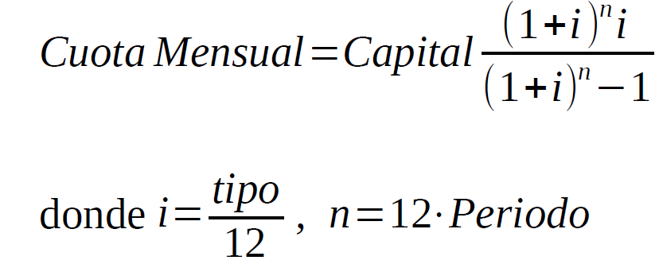

Y ahora, contestad con honestidad: ¿no os resulta aterrador que en el cálculo de vuestra cuota hipotecaria haya una potencia que eleva al número de meses implicados? Entonces, si el préstamo es a 20 años ¡¡Está elevando por 240!! Pues es lo que hay. La siguiente expresión traduce a R la fórmula del tipo de interés compuesto, que guarda en nuestra función llamada **Hipoteca**:

```r
Hipoteca <- function(Capital, Plazo, Tipo) {

  i=Tipo/12
  n=Plazo*12
  Cuota = Capital*(((1+i)^n)*i)/((1+i)^n-1)

  Salidas <- list(
    Cuota = Cuota,
    PagoTotal = Cuota*n,
    Intereses = Cuota*n - Capital)

  return(Salidas)
  }
```

Ya hemos programado nuestra función. La estructura ha quedado un poquito más compleja de lo que os habíamos anunciado al principio, consecuencia de una circunstancia que también conviene comentar: el `return` de la función debe ser único. Por ello, en un caso como este, en el que nos interesa extraer tres informaciones distintas (Cuota, PagoTotal e Intereses), debemos meter esos tres outputs dentro de una única lista (o también hubiera valido dentro de un mismo data.frame, o un vector…) y que el `return` sea la lista (data.frame/vector…). Sí, es un poquito más complejo, pero oye ¿esto es un taller avanzado o no?.

Ejemplos concretos. Imaginemos que pedimos 180 mil euros al banco, que iremos devolviendo en cómodas cuotas mensuales durante los próximos 25 años, a un tipo de interés del 3% anual. Como ya tenemos creada la función, para obtener las salidas que hemos definido, simplemente debemos escribir:

```r
Hipoteca(Capital=180000, Plazo=25, Tipo=0.03)
```

```
## $Cuota
## [1] 853.5804
##
## $PagoTotal
## [1] 256074.1
##
## $Intereses
## [1] 76074.11
```

Total, que en estas condiciones terminaremos pagando 256 mil euros, de los que 76 mil (aproximadamente el 30%) son intereses. Como siempre, os invitamos a correr el ejemplo en vuestra consola de R y a hacer las pruebas que consideréis oportunas. ¿Sabríais decir qué porcentaje suponen los intereses sobre el pago total, cuando el tipo de interés es el 5%? La respuesta os la facilitaremos más adelante.

## Bucles

Otra estructura que nos permite industrializar nuestros procesos son los bucles. Por no hacer el tema infinito, aquí vamos a hablar de un bucle en concreto, el bucle `for`, que nos permite repetir el mismo código un número predefinido de veces.

Un bucle `for` tiene tres partes fundamentales:

1. La secuencia de elementos a iterar
2. Las operaciones a realizar por cada elemento de la secuencia
3. El contenedor de los resultados (opcional)

La sintaxis, reducida al chasis, es así:

```
 for (selecciona elemento de la secuencia)
     {operaciones con el elemento}
```

Fíjate en los paréntesis y las llaves. Los resultados pueden ser impresos en la consola, o almacenados en un objeto. A continuación un ejemplo sencillo:

```r
for(numero in 1:10) { x <- (2*numero)
                      print(x)
                    }
```

```
## [1] 2
## [1] 4
## [1] 6
## [1] 8
## [1] 10
## [1] 12
## [1] 14
## [1] 16
## [1] 18
## [1] 20
```

## Combinando funciones y bucles

Si combinamos las dos estructuras podemos resolver/industrializar problemas complejos. En la siguiente pestaña mostraremos dos ejemplos concretos que nosotros utilizamos habitualmente en la producción estadística. Pongamos ahora un ejemplo más sencillo con la función **Hipotecas** que ya habíamos creado. El ejemplo va a consistir en hacer un recorrido entre tipos de interés 1% a 10%, de medio punto en medio punto porcentual y guardar cinco elementos en cada vuelta del bucle. Lo vamos a guardar todo en un data.frame llamado **fu_bu**, por ‘funciones y bucles’ (sí, se nos acabaron las ideas). Tres de los elementos que va a contener **fu_bu** ya nos los devuelve nuestra función (Cuota, PagoTotal, Intereses) y a eso le incorporaremos dos columnas adicionales, (1) el tipo de interés que corresponde con cada vuelta del bucle y (2) el porcentaje que suponen los intereses sobre el pago total.

De hecho, con la tabla que obtenemos como resultado, podemos responder ya a la pregunta que os habíamos planteado como reto. Con un tipo de interés del 5%, la proporción del pago total que son intereses es el 43%. Fijáos que si los tipos de interés fueran el 10% acabarías pagando al final de los 25 años 490.698€, de los que el 63% habrán ido a pagar intereses.

```r
fu_bu = data.frame()
Tipos = seq(from=0.01, to= 0.10, by=0.005)

for(i in Tipos) {
  Vuelta_i=Hipoteca(Capital=180000, Plazo=25, Tipo=i)
  Vuelta_i <- as.data.frame(Vuelta_i) %>% mutate(Proporcion=Intereses/PagoTotal,Tipo=i)
  fu_bu <- bind_rows(fu_bu,Vuelta_i)
}

fu_bu
```

```
##        Cuota PagoTotal Intereses Proporcion  Tipo
## 1   678.3704  203511.1  23511.13  0.1155275 0.010
## 2   719.8854  215965.6  35965.62  0.1665340 0.015
## 3   762.9378  228881.3  48881.34  0.2135663 0.020
## 4   807.5101  242253.0  62253.04  0.2569753 0.025
## 5   853.5804  256074.1  76074.11  0.2970785 0.030
## 6   901.1224  270336.7  90336.73  0.3341637 0.035
## 7   950.1063  285031.9 105031.89  0.3684917 0.040
## 8  1000.4985  300149.5 120149.54  0.4002989 0.045
## 9  1052.2621  315678.6 135678.62  0.4297998 0.050
## 10 1105.3575  331607.2 151607.25  0.4571892 0.055
## 11 1159.7425  347922.8 167922.76  0.4826438 0.060
## 12 1215.3729  364611.9 184611.87  0.5063244 0.065
## 13 1272.2026  381660.8 201660.77  0.5283770 0.070
## 14 1330.1841  399055.2 219055.24  0.5489346 0.075
## 15 1389.2692  416780.8 236780.76  0.5681183 0.080
## 16 1449.4088  434822.6 254822.63  0.5860381 0.085
## 17 1510.5535  453166.0 273166.04  0.6027946 0.090
## 18 1572.6540  471796.2 291796.20  0.6184793 0.095
## 19 1635.6613  490698.4 310698.40  0.6331759 0.100
```

#### Ejemplos funciones/bucles

En esta entrada vamos a proponer dos ejemplos, extraídos de nuestro trabajo, que combinan funciones y bucles.

1. El primero de ellos parte de los datos del Censo 2021. Vamos a generar todo un listado de tablas, en las que solamente cambia una de las variables de agupación.
2. El segundo ejemplo pretende realizar comprobaciones automatizadas en nuestros datos. Esto nos permitirá detectar por ejemplo, nuevos códigos en las variables. O variaciones sospechosas de un lote a otro.

**Ejemplo 1 - Generamos listado de tablas**

Supongamos que queremos extender el ejemplo que pusimos al hablar de la relación entre Excel y R. Deseamos obtener seis tablas, con datos procedentes del Censo 2021. En cada tabla queremos distinguir colectivos en base a tres características: el sexo, la provincia de residencia y una tercera variable que es específica para cada tabla. A continuación el listado de tablas que queremos elaborar:

- Cruce 1: Personas según sexo, provincia y grupo de edad
- Cruce 2: Personas según sexo, provincia y nacionalidad
- Cruce 3: Personas según sexo, provincia y nivel de estudios
- Cruce 4: Personas según sexo, provincia y estado civil
- Cruce 5: Personas según sexo, provincia y relación con la actividad
- Cruce 6: Personas según sexo, provincia y situación profesional

Podríamos programar el cálculo de estas tablas de forma individual, como hicimos en el ‘ejemplo Excel’, pero en esta sección lo vamos a hacer con la ayuda de funciones y bucles. El primer paso consistirá en cargar los datos necesarios y generar los grupos de edad a partir de la información de edades simples de la que disponemos (recuerda, al llevarte el ejemplo a R, debes poner la dirección de red correcta):

```r
load("C:/.../Censo2021.RData")
DATOS_HP <- DATOS_HP %>% mutate(VAREDAD_R = if_else(VAREDAD<16,'1',if_else(VAREDAD<65,'2','3')))
```

En segundo lugar, definimos un vector con el nombre de las variables que son específicas en cada tabla. Como ya podéis intuir, después vamos a montar un bucle `for` que vaya recorriendo cada elemento de este vector:

```r
VARIABLES <- c('VAREDAD_R','PNACIO','ESREAL_CNEDA','ECIVIL','RELA','SITU')
```

En tercer lugar, creamos una función que agregue por una variable genérica (VAR) de nuestro vector de variables

```r
calcula_tabla <- function(datos) {
  VAR=as.symbol(VARIABLES[i])
  tabla <- datos %>% group_by(CPRO,SEXO,CATEG=eval(VAR)) %>% summarise(personas = n()*10) %>% mutate(VAR=VARIABLES[i])
}
```

Y finalmente, con ayuda de (1) los datos que hemos cargado, (2) el vector de variables y (3) la función `calcula_tabla` que hemos creado, ya estamos en condiciones de meterlo todo dentro de un bucle, que genere en cada vuelta una de las tablas que deseábamos. Si corréis el ejemplo en vuestra consola, veréis que genera seis data.frames denominados “T_1” a “T_6”, con las provincias en columnas. Y estamos combinando junto a bucles y funciones, elementos de distintas librerías explicadas a lo largo del curso.

```r
# Ponemos todas las variables que queremos en el cruce en formato caracter.
  DATOS_HP <- DATOS_HP %>% mutate(PNACIO=as.character(PNACIO),ECIVIL=as.character(ECIVIL),RELA=as.character(RELA),SITU=as.character(SITU))

# Bucle que nos genera las seis tablas que queríamos.
# Ojo! Hemos incorporado el comando assign para poder generar unos nombres de tablas que son dependientes de i (la vuelta del bucle)
  for (i in 1:length(VARIABLES))  {

      NombreTabla <- paste("T_", i, sep = "")
      tabla <- calcula_tabla(DATOS_HP) %>% pivot_wider(names_from=CPRO, values_from=personas,values_fill=0)

      assign(NombreTabla, tabla)
    }
```

**Ejemplo 2 - Comprobaciones automatizadas**

Acabamos la sección con otro ejemplo. Vamos a utilizar las funciones y bucles para una utilidad en concreto: realizar comprobaciones. Conviene mencionar que también hay librerías de R especialmente diseñadas para hacer comprobaciones. Este es el caso del paquete `validate`, que ya tiene pre-definidas rutinas que te asisten en estos procesos.

Pero aquí vamos a diseñar nosotros una validación sencilla. Imaginemos que recibimos periodicamente los datos de un fenómeno. O que somos nosotros mismos los que realizamos periódicamente la estimación de un fenómeno. Aquí lo vamos a ilustrar con datos de dos lotes trimestrales de la EPA. Vamos a recorrer las distintas variables de nuestro set de datos, agrupando por las distintas categorías que admite cada variable. Después vamos a comparar los datos de un periodo y del siguiente, estabeciendo un umbral de tolerancia y pidiéndole que nos muestre los datos extraños/sospechosos (aquellos casos en los que la diferencia entre el periodo anterior y el nuevo supera dicho umbral).

El primer paso será, como siempre, cargar los datos. Os los hemos facilitado en el fichero EPA_Comprobaciones.RData que contiene el material del Taller4 (Tratamiento avanzado de datos). Nota: la expresión `options(scipen=999)` lo que hace es mostrarnos siempre decimales, para evitar la notación científica… quizás de mayores lleguemos a ser científicos de datos, pero lo que es por ahora nosotros lo vemos más claro con decimales.

```r
#Paso 1 - Cargamos datos
          options(scipen=999)
          load("C:/.../EPA_Comprobaciones.RData")

#Paso 2 - La lista de variables la extraemos del propio data.frame
#         Vamos a excluir cinco variables de la lista de variables a recorrer. Motivo: más que categorías, son datos únicos de cada registro
          Lista <- colnames(Microdatos_3T2023 %>% select(-c(NVIVI,HORASP,HORASH,HORASE,FACTOREL)))
```

Creamos nuestra función, a la que denominamos ‘EPA_Compru’. Como podéis ver, la función selecciona una variable genérica de la lista (VAR). Agrupamos en los dos lotes por esa variable y generamos dos estadísticos resúmen de esa agrupación: la muestra asociada a cada categoría y la estimación poblacional, utilizando el factor de elevación de cada observación. Finalmente, generamos un data.frame llamado “Vueltai”, con toda la información (nombre de la variable, código de la categoría, tamaños muestrales en los dos lotes, estimación del valor poblacional en los dos lotes y las tasas de variación intertrimestrales):

```r
EPA_Compru <- function(i) {

  VAR <- as.symbol(Lista[i])

  Dato_3T2023 <- Microdatos_3T2023 %>% group_by(CODIGO=eval(VAR)) %>% summarise(Muestra_3T2023=n(), Estimacion_3T2023=sum(FACTOREL)) %>% ungroup()
  Dato_4T2023 <- Microdatos_4T2023 %>% group_by(CODIGO=eval(VAR)) %>% summarise(Muestra_4T2023=n(), Estimacion_4T2023=sum(FACTOREL)) %>% ungroup()

  Vueltai <- full_join(Dato_3T2023,Dato_4T2023) %>% mutate(TVAR_MUESTRA=(Muestra_4T2023/Muestra_3T2023-1)*100,
                                                           TVAR_ESTIMACION=(Estimacion_4T2023/Estimacion_3T2023-1)*100,
                                                           VARIABLE=Lista[i])

  return(Vueltai)
  }
```

Ahora simplemente vamos a definir un bucle que recorra las distintas variables y que vaya haciendo la operación que hemos definido en la función. En cada vuelta del bucle, vamos seleccionando una variable en concreto y para ella hacemos lo siguiente: (1) Gracias a nuestra función EPA_Compru, calculamos el número de elementos asociados a las categorías de la variable. (2) Ojo! En cada vuelta del bucle se agrupa por una variable distinta. Por ello, antes de que el bucle pase a la siguiente vuelta, nosotros querremos guardar el resultado. Esto lo hacemos en un data.frame único (Resultado), que empezamos definiendo como un data.frame vacío:

```r
Resultado <- data.frame()

for (i in 1:length(Lista)) {
  Resultado  <- bind_rows(Resultado,EPA_Compru(i))
  }
```

Y ya sólo nos resta definir los umbrales de tolerancia. En primer lugar, filtramos los códigos con una frecuencia en alguno de los dos lotes superior a 10 casos. Por lo demás, nos quedamos con las variaciones superiores al 20% respecto del trimestre anterior. En el caso en el que la muestra sea pequeña (menos de 100 casos), vamos a subir ese umbral de tolerancia hasta el 50%. Por último, le vamos a pedir que nos muestre también los casos en los que el resultado es un nulo, pues eso es indicativo de que el código en cuestión ha aparecido nuevo.

```r
Datos_Revisar <- Resultado %>% filter(Muestra_3T2023>10 | Muestra_4T2023>10) %>%
                               filter(is.na(Muestra_3T2023) |
                                      is.na(Muestra_4T2023) |
                                      TVAR_ESTIMACION >  50 |
                                      TVAR_ESTIMACION < -50 |
                                      TVAR_ESTIMACION >  20  & Muestra_4T2023>100 |
                                      TVAR_ESTIMACION < -20  & Muestra_4T2023>100)
```

Si habéis corrido todo el ejemplo en vuestra consola, habréis podido comprobar que el data.frame “Resultados” tenía 993 registros. De ellos, no cumplen con el umbral de tolerancia los 73 registros que contiene el data.frame “Datos_Revisar”. Estos registros serán los que tengamos que mirar con detenimiento para ver qué está pasando con ellos (qué es lo que explica esa elevada tasa de variación inter-trimestral).

# Incorpora ChatGPT

Ahora vamos a hablar de una herramienta muy potente, que facilita crear código: chatGPT, a través de una conversación en “lenguaje natural”. Para ello, tenemos la forma directa y la indirecta. La ‘forma directa’ nos la ofrece la librería `gptstudio`. Con ella, te instalas un addin que te permite pedirle cosas a chatGPT directamente desde tu sesión de RStudio y que se ejecuten ahí mismo, sin salir de tu sesión de trabajo. Todo genial, si no fuera porque necesitas la versión premium para que esto funcione sin restricciones.

[figure not shown]

Por ello, lo que os vamos a proponer es algo un poco menos ‘loco’, pero que funciona muy bien. Puedes abrir chatGPT en tu navegador. Si no tienes creada una cuenta, tendrás que empezar por ahí. En el momento de escribir estas líneas la versión gratuita de chatGPR es la versión 4o y la versión premium/pago es la versión chatGPR Plus. Nosotros vamos a usar **chatGPT-4o**. Una vez tienes la cuenta operativa, simplemente chatea con el bot y pídele que te genere el código para hacer lo que necesites. El bot te propondrá como resultado unas líneas de código. Finalmente, solo tendrás que llevarte esas líneas a tu sesión de RStudio y correrlas allí (copia en chatGPT, pega en RStudio y dale a **enter**). Pongamos un ejemplo, paso a paso:

- Abre una sesión en RStudio y carga los datos del Censo 2021

  ```r
  library(tidyverse)
  load("C:/.../Censo2021.RData")
  ```

  Y ahora te planteas a tí mismo el siguiente reto: A partir del dataframe DATOS_VE, quiero escribir el código R que realice un conteo de casos y la superficie media en cada provincia (CPRO). Ah! y la variable que recoge, como carácter, el número de viviendas es la variable llamada SUPERF.
- Para contestar a la pregunta, ve a la página de openAI, que son los creadores de chatGPT. Ahora simplemente trasládale tu duda (copia-pega la duda en el siguiente cuadro y dale a enter):

[figure not shown]

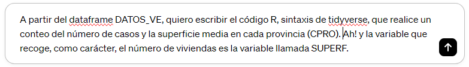

- Y aquí la respuesta. ¡Ojo! Que el bot tiene memoria contextual. Esto quiere decir que según progresa el hilo de conversación y le vas pidiendo cosas en la conversación, va entendiendo mejor lo que quieres. O podríamos decir que ‘te va conociendo’ e incorpora a su algoritmo cómo te gusta programar a ti. Si ya te ha calado y eres un tidyverse-lover, tenderá a ponérnoslo con esa sintaxis, pero quizás a vosotros os genere un código distinto, con sintaxis de R `base`. Es por eso que hemos querido especificarle en la pregunta qué sintaxis queremos que nos devuelva (`tidyverse`). Podéis probar a seguir con la conversación y pedir por ejemplo que os muestre el código `data.table` que haría falta para lanzar la misma sentencia. O podéis pedirle que os genere el código en otros lenguajes (SAS, Python, SQL… como queráis).

  Y ahora viene al caso recordar una reflexión que hacíamos al hablar de la librería `dbplyr`. En cualquier análisis de datos hay dos dificualtades, (1) saber qué quieres hacer. Esta primera dificultad tiene un carácter cognitivo y es propia de cada ámbito temático. (2) La segunda dificultad es hacerlo. Esta segunda dificultad tiene un carácter computacional. Y la filosofía de `tidyverse` es precisamente simplificar al máximo la parte computacional, para dedicar el tiempo a lo que de verdad importa, que no es otra cosa que pensar qué quieres hacer. En este sentido tanto `tidyverse` como chatGPT son herramientas útiles que facilitan a cualquier usuario superar las limitaciones que antes le imponía la cibernética. Ahora, ¡A volar!

[figure not shown]